# Advanced R course exercises

## Exercise 1

Read in the data we were given

```r
setwd("o:/Training/Advanced R/Advanced R Data/")
read.delim("methylation.txt") -> methylation
read.delim("expression.txt") -> expression
```

Remove any lines from the methylation data where the promoter methylation equals -1 (ie not actually measured), and see what effect this has on the number of rows of data we have

```r
nrow(methylation)
```

```
## [1] 25077
```

```r
methylation[methylation$Promoter_meth != -1,] -> methylation
nrow(methylation)
```

```
## [1] 23974
```

Deduplicate the expression data based on probe names. We’re going to leave one instance of each duplicated name behind.

```r
expression[!duplicated(expression$Probe),] -> expression
```

Find out how many olfactory receptors we have in our expression data

```r
sum(grepl("Olfr",expression$Probe))
```

```
## [1] 1118
```

Change the chromosome names from 1,2,3 etc, to chr1,chr2,chr3 etc.

```r
expression$Chromosome <- paste("chr",expression$Chromosome,sep="")
```

Find out which probes are present in the methylation data, but not the expression data

```r
methylation$Probe[!(methylation$Probe %in% expression$Probe)]
```

```
##   [1] AC027184.1      AC044807.1      AC044864.2      AC069308.1
##   [5] AC087117.2      AC087556.1      AC087898.1      AC093346.1
##   [9] AC099934.1      AC100600.1      AC102240.1      AC102463.1
##  [13] AC102525.1      AC102689.1      AC102815.1      AC103359.1
##  [17] AC103368.1      AC107711.2      AC107770.1      AC108409.1
##  [21] AC108434.1      AC109138.1      AC109196.1      AC110211.1
##  [25] AC110235.1      AC113244.1      AC113316.1      AC113598.1
##  [29] AC114657.1      AC114668.1      AC115005.1      AC115697.1
##  [33] AC117657.1      AC119813.1      AC120136.3      AC120540.1
##  [37] AC121599.1      AC121600.1      AC121784.1      AC121784.4
##  [41] AC122247.1      AC122490.1      AC122520.2      AC122537.1
##  [45] AC122546.1      AC122860.1      AC123610.1      AC123616.1
##  [49] AC123882.1      AC124180.1      AC124466.1      AC124472.1
##  [53] AC124489.1      AC124584.1      AC124613.1      AC124807.1
##  [57] AC125201.1      AC126679.1      AC126690.2      AC127419.1
```

[output cut: 70 more lines]

Merge the expression and methylation datasets together. The only column name in common is Probe, which is what we want to merge on anyway.

```r
merge(expression,methylation) -> merged.data
```

## Exercise 3

Loop over the expression/methylation columns to calculate the range of values in each.

```r
apply(merged.data[,6:8],2,range)
```

```
##      Expression Gene_body_meth Promoter_meth
## [1,]  -9.743026              0             0
## [2,]  11.321041            100           100
```

Calculate the mean gene body methylation for each chromosome, then plot this as a barplot

```r
tapply(merged.data$Gene_body_meth,merged.data$Chromosome,mean)
```

```
##     chr1    chr10    chr11    chr12    chr13    chr14    chr15    chr16
## 43.58484 46.10247 39.33736 45.42464 42.77284 41.64486 40.85106 44.89734
##    chr17    chr18    chr19     chr2     chr3     chr4     chr5     chr6
## 42.08896 43.12389 43.66956 39.22779 40.02630 41.98396 48.95195 40.50904
##     chr7     chr8     chr9    chrMT     chrX
## 41.69334 47.86813 43.31258 16.70353 40.79321
```

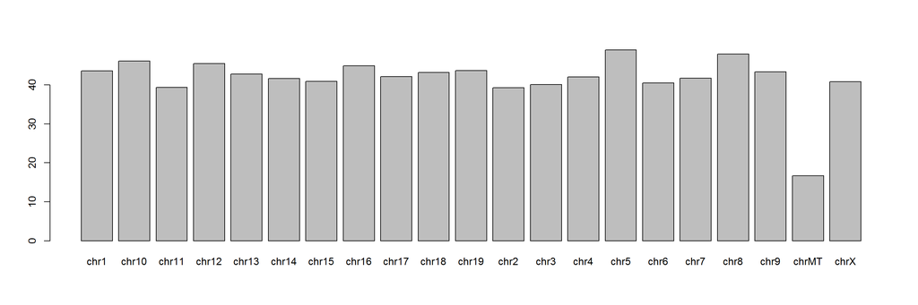

```r
barplot(tapply(merged.data$Gene_body_meth,merged.data$Chromosome,mean))
```

## Exercise 4

Set up a function to calculate the SEM

```r
sem <- function (x,absent=NA) {

  if (sum(is.na(x)) > 0) return (absent)

  return (sd(x)/sqrt(length(x)))
}
```

Calculate the gene body methylation SEM for each chromosome.

```r
tapply(merged.data$Gene_body_meth,merged.data$Chromosome,sem)
```

```
##      chr1     chr10     chr11     chr12     chr13     chr14     chr15
## 0.8997813 1.0365418 0.7527817 1.2446569 1.1330741 1.1697267 1.1343304
##     chr16     chr17     chr18     chr19      chr2      chr3      chr4
## 1.2531691 0.9920431 1.4073080 1.1942370 0.7315191 0.9978256 0.8167108
##      chr5      chr6      chr7      chr8      chr9     chrMT      chrX
## 0.8783216 0.9507895 0.7829240 0.9606002 0.9308829 3.7439534 1.0516666
```

## Exercise 5

Install the vioplot library and use it to draw violin plots for the 3 datasets we have.

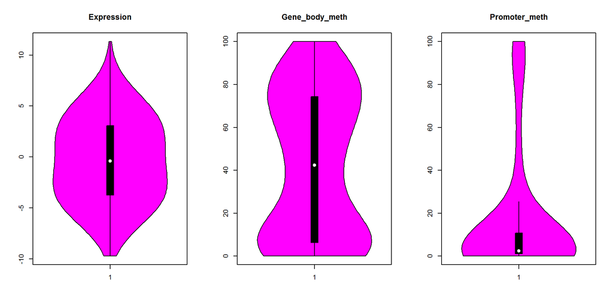

```r
library(vioplot)
par(mfrow=c(1,3))
sapply(colnames(merged.data)[6:8],function(x) {
  vioplot(merged.data[[x]])
  title(x)
}
)
```